# Mini projet 1: qPCR

Author

Mateus Auza Cruz

## Libraries used

```r
library(psych)
library(FactoMineR)
library(factoextra)
library(ggplot2)
library(dplyr)
library(caret)
```

# Data import

Data are imported and the Group variable is converted into a factor. The dataset is then split into Disease and Control groups.

```r
omics <- read.csv("data_qPCR.csv", sep = ";")
omics$Group <- factor(omics$Group)
omics.disease <- omics[omics$Group == "Disease", ]
omics.control <- omics[omics$Group == "Control", ]
```

# 1. Exploration of data distributions by group

## Disease group

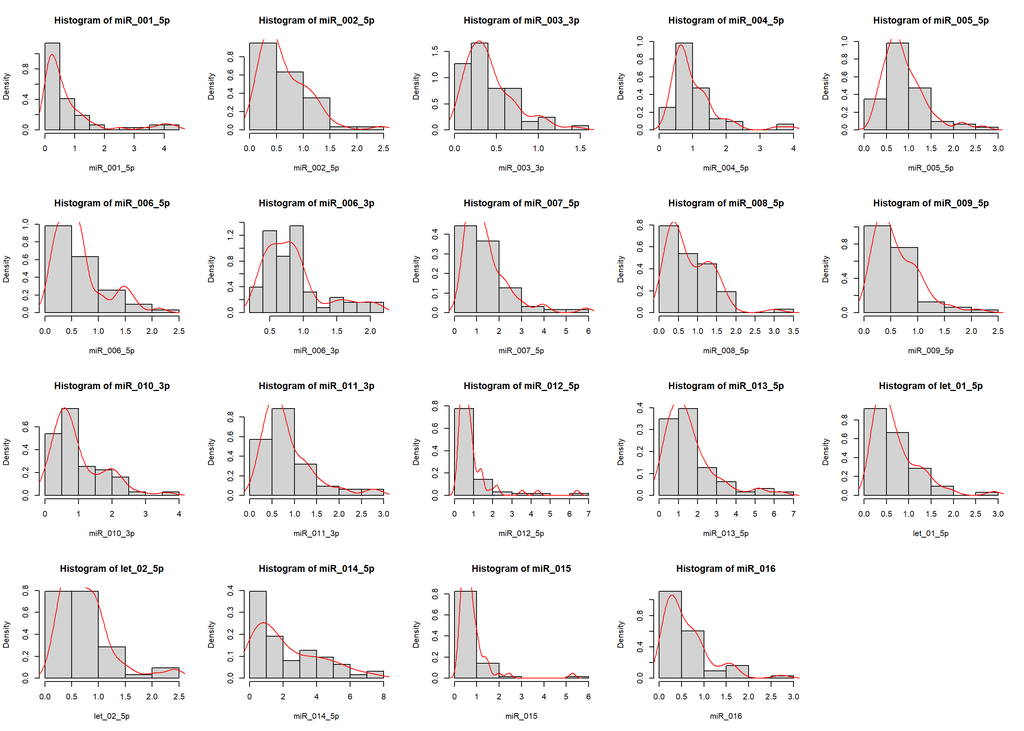

```r
# Disease Group

par(mfrow = c(4, 5))
for (i in 3:dim(omics)[2]) {
  hist(omics.disease[, i], main = paste("Histogram of", colnames(omics.disease)[i]), freq = F, xlab = paste(colnames(omics.disease)[i]))
  lines(density(omics.disease[, i]), col = "red")
}
```

We observe that most miRNA distributions are right-skewed and that all values are positive. Therefore, the data are log-transformed.

## Control group

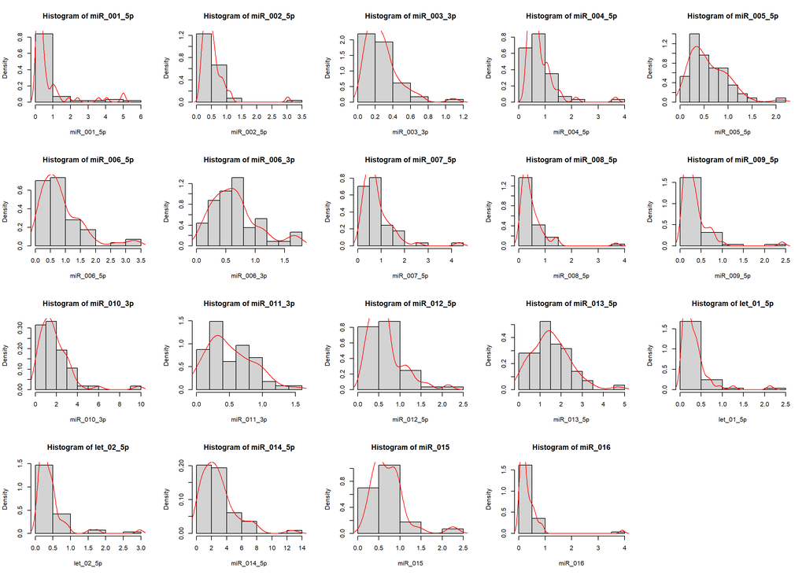

```r
par(mfrow = c(4, 5))
for (i in 3:dim(omics)[2]) {
  hist(omics.control[, i], main = paste("Histogram of", colnames(omics.control)[i]), freq = F, xlab = paste(colnames(omics.control)[i]))
  lines(density(omics.control[, i]), col = "red")
}
```

For the same reasons as above, the data are log-transformed. Because of this transformation, zero values must be handled, as suggested in the instructions. Zero values are replaced by a small constant (0.01) before log transformation.

```r
omics[, 3:21][omics[, 3:21] == 0] <- 0.01
log.omics <- cbind(omics[, c(1, 2)], log(omics[, 3:21]))

log.omics.disease <- log.omics[log.omics$Group == "Disease", ]
log.omics.control <- log.omics[log.omics$Group == "Control", ]
```

# 2. Descriptive statistics of each miRNA by group

## Disease group

#### Tables

Descriptive statistics (mean, median, standard deviation, etc.) are computed for each miRNA in the Disease group using log-transformed data.

```r
describe(log.omics.disease[, 3:21])
```

```
           vars  n  mean   sd median trimmed  mad   min  max range  skew
miR_001_5p    1 63 -0.85 1.10  -0.96   -0.90 1.07 -2.67 1.48  4.16  0.36
miR_002_5p    2 63 -0.66 0.69  -0.69   -0.65 0.84 -2.14 0.89  3.03 -0.09
miR_003_3p    3 63 -1.07 0.67  -1.04   -1.07 0.81 -2.54 0.35  2.89 -0.08
miR_004_5p    4 63 -0.16 0.57  -0.23   -0.18 0.56 -1.40 1.37  2.77  0.34
miR_005_5p    5 63 -0.23 0.50  -0.24   -0.23 0.46 -1.32 0.97  2.30  0.03
miR_006_5p    6 63 -0.72 0.77  -0.63   -0.69 0.64 -3.23 0.75  3.99 -0.50
miR_006_3p    7 63 -0.28 0.49  -0.23   -0.30 0.47 -1.29 0.75  2.04  0.25
miR_007_5p    8 63  0.13 0.62   0.13    0.11 0.65 -1.12 1.77  2.90  0.27
miR_008_5p    9 63 -0.50 0.76  -0.51   -0.47 1.00 -1.98 1.10  3.08 -0.14
miR_009_5p   10 63 -0.73 0.69  -0.75   -0.72 0.85 -2.42 0.75  3.17 -0.13
miR_010_3p   11 63 -0.35 0.91  -0.32   -0.26 0.70 -3.93 1.29  5.21 -1.10
miR_011_3p   12 63 -0.38 0.62  -0.39   -0.38 0.67 -1.91 1.05  2.96  0.03
miR_012_5p   13 63 -0.42 0.73  -0.58   -0.47 0.56 -2.14 1.86  3.99  0.68
miR_013_5p   14 63  0.10 0.95   0.21    0.18 0.84 -3.01 1.84  4.85 -1.08
let_01_5p    15 63 -0.59 0.68  -0.61   -0.60 0.71 -2.22 1.07  3.29  0.09
let_02_5p    16 63 -0.46 0.60  -0.37   -0.46 0.59 -1.73 0.90  2.64 -0.01
miR_014_5p   17 63  0.27 1.23   0.49    0.37 1.36 -4.62 1.98  6.60 -1.10
miR_015      18 63 -0.46 0.59  -0.49   -0.50 0.55 -1.58 1.66  3.24  0.79
miR_016      19 63 -0.82 0.83  -0.81   -0.82 0.94 -2.54 1.00  3.54 -0.05
           kurtosis   se
miR_001_5p    -0.67 0.14
miR_002_5p    -0.74 0.09
miR_003_3p    -0.68 0.08
miR_004_5p    -0.04 0.07
miR_005_5p    -0.27 0.06
miR_006_5p     0.48 0.10
miR_006_3p    -0.55 0.06
miR_007_5p    -0.31 0.08
miR_008_5p    -1.09 0.10
miR_009_5p    -0.67 0.09
miR_010_3p     2.51 0.12
miR_011_3p    -0.15 0.08
miR_012_5p     1.02 0.09
miR_013_5p     1.87 0.12
let_01_5p     -0.54 0.09
let_02_5p     -0.42 0.08
miR_014_5p     2.18 0.15
miR_015        1.31 0.07
miR_016       -0.87 0.11
```

#### Plots

Histograms and density curves are used to visualize the distribution of log-transformed miRNA expression levels.

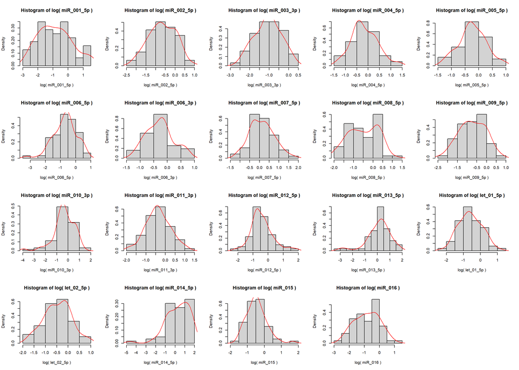

```r
par(mfrow = c(4, 5))
for (i in 3:ncol(log.omics.disease)) {
  hist(log.omics.disease[, i],
    main = paste("Histogram of log(", colnames(log.omics.disease)[i], ")"),
    xlab = paste("log(", colnames(log.omics.disease)[i], ")"),
    freq = FALSE
  )

  lines(density(log.omics.disease[, i], na.rm = TRUE),
    col = "red"
  )
}
```

## Control group

#### Tables

Descriptive statistics are computed for each miRNA in the Control group.

```r
describe(log.omics.control[, 3:21])
```

```
           vars  n  mean   sd median trimmed  mad   min  max range  skew
miR_001_5p    1 57 -1.06 1.11  -1.29   -1.14 0.83 -3.93 1.61  5.54  0.55
miR_002_5p    2 57 -0.84 0.56  -0.88   -0.85 0.45 -1.91 1.11  3.02  0.52
miR_003_3p    3 57 -1.50 0.68  -1.40   -1.50 0.66 -3.01 0.08  3.09 -0.14
miR_004_5p    4 57 -0.42 0.50  -0.48   -0.46 0.47 -1.22 1.30  2.52  0.92
miR_005_5p    5 57 -0.71 0.66  -0.71   -0.71 0.82 -1.98 0.73  2.71 -0.08
miR_006_5p    6 57 -0.52 1.00  -0.39   -0.44 0.81 -4.61 1.21  5.82 -1.28
miR_006_3p    7 57 -0.64 0.71  -0.49   -0.60 0.58 -2.54 0.54  3.09 -0.70
miR_007_5p    8 57 -0.44 0.69  -0.42   -0.44 0.69 -1.98 1.46  3.44  0.08
miR_008_5p    9 57 -1.05 0.81  -1.07   -1.07 0.83 -2.83 1.30  4.13  0.26
miR_009_5p   10 57 -1.41 0.81  -1.49   -1.40 0.74 -3.52 0.88  4.40  0.03
miR_010_3p   11 57  0.26 0.89   0.40    0.33 0.81 -1.91 2.28  4.19 -0.62
miR_011_3p   12 57 -1.07 1.15  -0.88   -0.87 0.77 -4.62 0.41  5.03 -1.68
miR_012_5p   13 57 -0.63 0.61  -0.58   -0.61 0.45 -2.22 0.76  2.98 -0.28
miR_013_5p   14 57  0.17 0.87   0.35    0.29 0.57 -3.01 1.54  4.56 -1.58
let_01_5p    15 57 -1.47 0.79  -1.53   -1.50 0.78 -3.01 0.75  3.77  0.37
let_02_5p    16 57 -1.19 0.79  -1.19   -1.21 0.74 -3.23 1.09  4.32  0.21
miR_014_5p   17 57  0.71 0.92   0.88    0.76 0.72 -1.79 2.54  4.32 -0.59
miR_015      18 57 -0.46 0.52  -0.43   -0.45 0.51 -1.91 0.82  2.73 -0.10
miR_016      19 57 -1.55 0.87  -1.58   -1.59 0.99 -3.01 1.36  4.37  0.63
           kurtosis   se
miR_001_5p     0.38 0.15
miR_002_5p     1.07 0.07
miR_003_3p    -0.47 0.09
miR_004_5p     0.92 0.07
miR_005_5p    -1.00 0.09
miR_006_5p     3.26 0.13
miR_006_3p     0.34 0.09
miR_007_5p     0.01 0.09
miR_008_5p    -0.03 0.11
miR_009_5p     0.26 0.11
miR_010_3p     0.17 0.12
miR_011_3p     2.66 0.15
miR_012_5p     0.13 0.08
miR_013_5p     2.81 0.11
let_01_5p     -0.20 0.10
let_02_5p      0.69 0.10
miR_014_5p    -0.17 0.12
miR_015        0.30 0.07
miR_016        0.38 0.12
```

#### Plots

Histograms and density curves are shown for the log-transformed miRNA expression levels in the Control group.

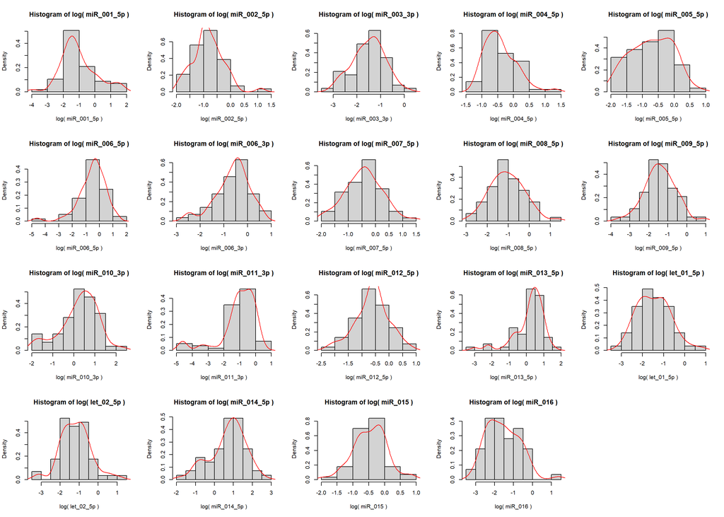

```r
par(mfrow = c(4, 5))
for (i in 3:ncol(log.omics.control)) {
  hist(log.omics.control[, i],
    main = paste("Histogram of log(", colnames(log.omics.control)[i], ")"),
    xlab = paste("log(", colnames(log.omics.control)[i], ")"),
    freq = FALSE
  )

  lines(density(log.omics.control[, i], na.rm = TRUE),
    col = "red"
  )
}
```

# 3. Identification and removal of outliers with justification

Since the distributions are approximately symmetric, outliers are detected using the z-score method with a threshold of 3.

```r
outlier.z <- function(x, cutoff = 3) {
  z <- (x - mean(x, na.rm = TRUE)) / sd(x, na.rm = TRUE)
  abs(z) > cutoff
}
outliers <- lapply(log.omics[, 3:21], outlier.z)

sapply(outliers, sum)
```

```
miR_001_5p miR_002_5p miR_003_3p miR_004_5p miR_005_5p miR_006_5p miR_006_3p
         0          0          0          0          0          1          3
miR_007_5p miR_008_5p miR_009_5p miR_010_3p miR_011_3p miR_012_5p miR_013_5p
         0          0          1          1          3          1          3
 let_01_5p  let_02_5p miR_014_5p    miR_015    miR_016
         0          1          1          1          0
```

```r
log.omics.clean <- log.omics
for (i in 3:21) {
  log.omics.clean[outliers[[i - 2]], i] <- NA
}
head(log.omics.clean)
```

```
    Group Identifier miR_001_5p  miR_002_5p  miR_003_3p  miR_004_5p  miR_005_5p
1 Disease          1  0.3136824 -1.32495470 -0.81412908  0.19139279 -0.21407232
2 Control          2 -0.8595915 -0.54325412 -0.93191211 -0.65049965 -0.61345838
3 Disease          3  0.1241406  0.52087199  0.01393742  0.17499898  0.26201036
4 Disease          4  0.1327986 -0.85959145 -0.98320541 -0.14345475 -0.74959056
5 Disease          5  0.5609920  0.04264753 -0.00567105  0.44811264 -0.00567105
6 Control          6 -1.1242840 -0.63180752 -1.21959419  0.06133966 -0.27698615
   miR_006_5p miR_006_3p miR_007_5p miR_008_5p  miR_009_5p miR_010_3p
1 -0.63180752 -0.2140723 -0.2769861 -1.0654435 -1.25349574 -0.4464043
2 -0.57774030  0.1413824 -0.2513437 -0.3722963 -0.66954785 -0.7087686
3 -0.49365718 -0.1321552  0.7953088  0.4226336  0.47907486 -0.8831219
4 -0.35811169 -0.1099321 -0.1434548 -0.7921502 -0.88312195 -0.9832054
5 -0.43113682 -0.1099321  0.4354542  0.4972022 -0.04608059         NA
6  0.04264753 -0.2140723 -0.3441254 -0.4311368 -0.77064397  2.2789315
   miR_011_3p miR_012_5p miR_013_5p  let_01_5p   let_02_5p miR_014_5p
1 -0.08819207  0.3350355  0.1667002 -1.0098737 -0.95722992  0.5031724
2 -0.66954785 -0.6889659  1.0316976 -0.6134584 -0.34412545 -0.6889659
3  0.07055632 -0.5777403  0.2695576  0.6775258 -0.03582409 -0.6695478
4  0.07055632 -0.1664443  0.4972022 -0.6889659 -1.03727263 -0.7087686
5  0.74050060  0.3559422 -0.7706440  0.4030890 -0.14345475  0.6522080
6 -0.15488345  0.1832295  0.8172877 -0.8831219 -0.85959145  0.1667002
      miR_015    miR_016
1 -0.12098190 -1.3249547
2 -0.66954785 -1.4019157
3 -0.29005823  0.4972022
4 -0.38668506 -0.9572299
5  0.35594218  0.4354542
6 -0.06691468 -0.6134584
```

# 4. Hypothesis tests comparing the two groups for each miRNA

Hypothesis testing is performed by comparing the Control and Disease groups for each miRNA using log-transformed data. The null hypothesis is that the mean expression levels are equal between the two groups.

Following outlier removal, a two-sided t-test will be performed for each miRNA. Distributions were found to be sufficiently symmetric upon visual inspection to satisfy the assumption of normality without requiring further formal testing (shapiro-Wilk test or Q-Q plots).

```r
t.test.results <- sapply(3:21, function(i) {
  t.test(log.omics.clean[[i]] ~ log.omics.clean$Group)$p.value
})

t.test.results
```

```
 [1] 2.873405e-01 1.268039e-01 6.543654e-04 9.164415e-03 1.915741e-05
 [6] 7.602005e-02 1.193086e-02 7.676246e-06 2.052601e-04 5.645195e-06
[11] 5.895318e-04 3.965384e-04 1.504009e-01 8.388386e-01 2.969343e-09
[16] 2.819341e-07 4.600092e-02 7.137297e-01 9.854064e-06
```

miRNAs with a p-value below 0.05 reject the null hypothesis, indicating a significant difference in mean expression between the Control and Disease groups.

```r
colnames(log.omics.clean)[which(t.test.results < 0.05) + 2]
```

```
 [1] "miR_003_3p" "miR_004_5p" "miR_005_5p" "miR_006_3p" "miR_007_5p"
 [6] "miR_008_5p" "miR_009_5p" "miR_010_3p" "miR_011_3p" "let_01_5p"
[11] "let_02_5p"  "miR_014_5p" "miR_016"
```

# 5. PCA analysis and visualization of the results

We first examine the scree plot in order to determine how many principal components should be retained.

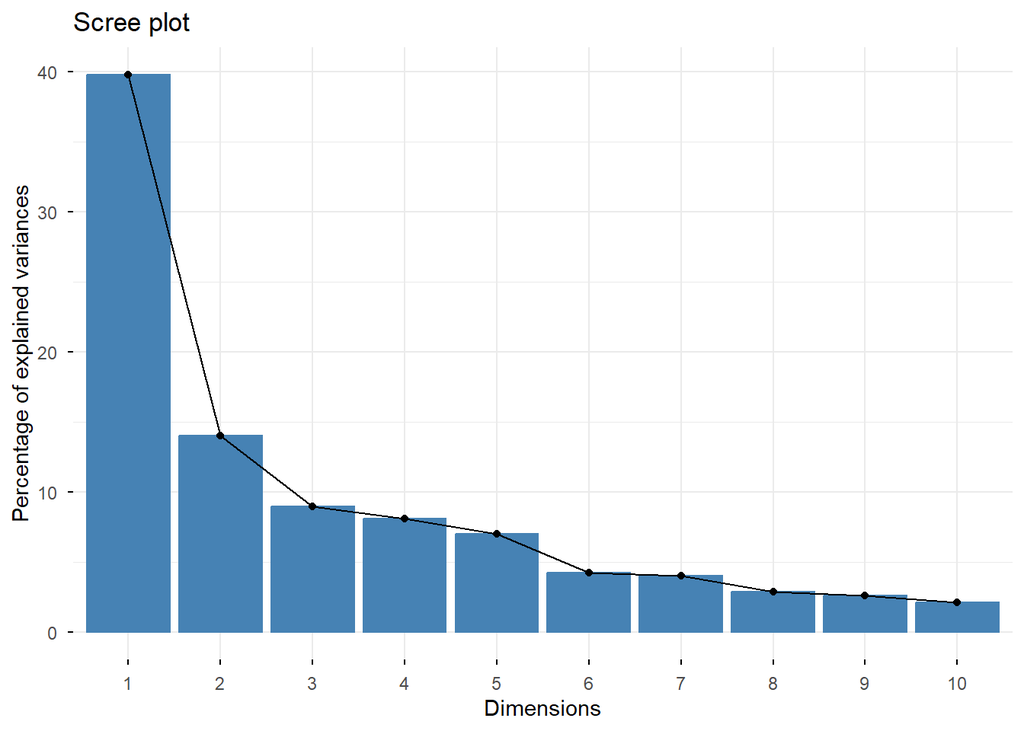

```r
omics.pca <- PCA(na.omit(log.omics.clean[, -2]), scale.unit = T, quali.sup = 1, graph = F)
omics.colors <- c(Control = "#1f77b4", Disease = "#d62728")

fviz_eig(omics.pca)
```

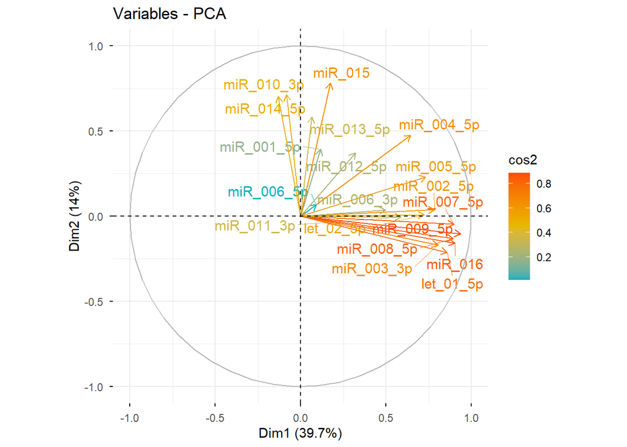

```r
fviz_pca_var(
  omics.pca,
  axes = c(1, 2),
  col.var = "cos2",
  gradient.cols = c("#00AFBB", "#E7B800", "#FC4E07"),
  repel = TRUE
)
```

The first principal component explains approximately 39.7% of the total variance, while the second explains approximately 14%. Together, the first two components explain 53.7% of the variance. This proportion is acceptable in the context of omics data, which are typically noisy and high-dimensional.

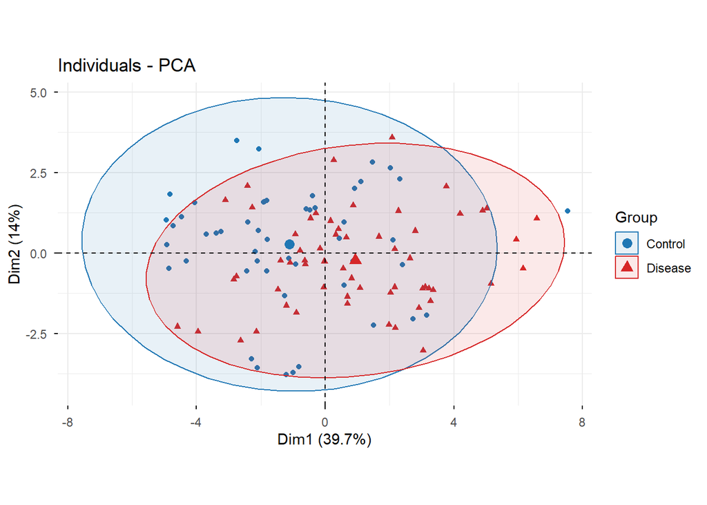

```r
fviz_pca_ind(
  omics.pca,
  col.ind = na.omit(log.omics.clean[, -2])$Group,
  label = "none",
  addEllipses = TRUE,
  legend.title = "Group"
) +
  coord_fixed() +
  scale_color_manual(values = omics.colors) +
  scale_fill_manual(values = omics.colors)
```

# 6. Clustering analysis and comparison with biological groups

Hierarchical clustering is performed using Ward’s method on scaled, log-transformed expression data.

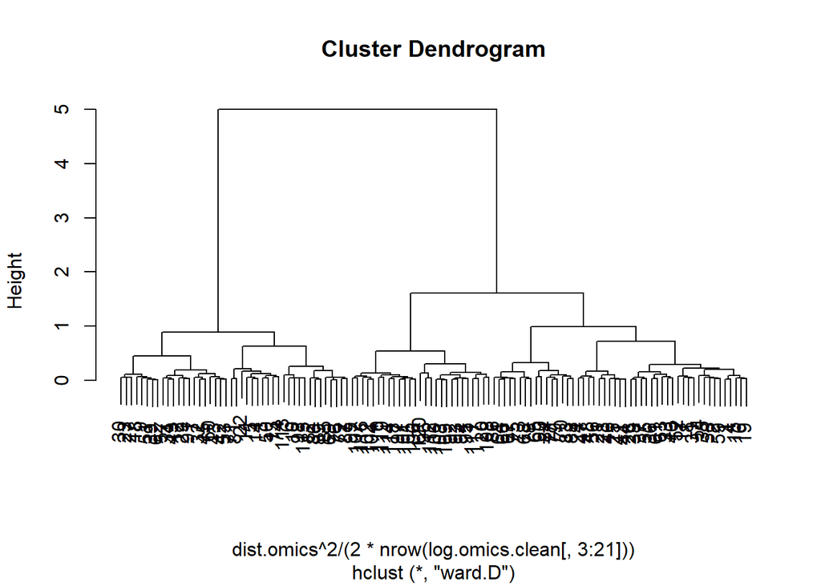

```r
dist.omics <- dist(scale(log.omics.clean[, 3:21]))

merge <- hclust(
  dist.omics^2 / (2 * nrow(log.omics.clean[, 3:21])),
  method = "ward.D"
)
plot(merge)
```

The resulting dendrogram is cut into two clusters, corresponding to the expected number of biological groups.

Cluster assignments are compared with the known group labels (Control vs Disease) using a confusion matrix. This comparison allows us to evaluate how well the unsupervised clustering recovers the original biological grouping.

```r
clusters <- cutree(merge, k = 2)

omics_df <- log.omics.clean |>
  mutate(
    hclusters = clusters,
    group = log.omics.clean$Group # your control/disease column
  ) |>
  group_by(group, hclusters) |>
  mutate(n = n()) |>
  arrange(hclusters, desc(n)) |>
  group_by(hclusters) |>
  mutate(
    hclust_predicted_group = group[1]
  ) |>
  ungroup()


confusionMatrix(
  data = omics_df$hclust_predicted_group,
  reference = omics_df$group
)
```

```
Confusion Matrix and Statistics

          Reference
Prediction Control Disease
   Control      44      32
   Disease      13      31

               Accuracy : 0.625
                 95% CI : (0.532, 0.7117)
    No Information Rate : 0.525
    P-Value [Acc > NIR] : 0.01732

                  Kappa : 0.2599

 Mcnemar's Test P-Value : 0.00729

            Sensitivity : 0.7719
            Specificity : 0.4921
         Pos Pred Value : 0.5789
         Neg Pred Value : 0.7045
             Prevalence : 0.4750
         Detection Rate : 0.3667
   Detection Prevalence : 0.6333
      Balanced Accuracy : 0.6320

       'Positive' Class : Control
```

# 7. Conclusion

Although several miRNAs show statistically significant differences between Control and Disease groups, their overall discriminative power is limited. The classification model achieves a moderate accuracy (62.5%), only slightly above the no-information rate, with a low Kappa value (0.26), indicating weak agreement beyond chance. Sensitivity is higher for Control samples than for Disease samples, leading to frequent misclassification of affected individuals.

Overall, despite differential expression of some miRNAs, **the results do not support the presence of robust biomarkers capable of reliably distinguishing Disease from Control individuals**, and instead point to biological heterogeneity within the Disease group.